# Datos vinculados en la Web: de JSON a JSON-LD y RDF

Fuentes de Datos Biomédicos y Web Semántica (#8235) · Grado en Ingeniería de la Salud

Dr. Antonio Canepa-Oneto

“5º Semestre / Curso 2026-2027”

# Antes de empezar

En esta práctica vais a trabajar con un mismo conjunto de datos a **tres niveles** distintos de interpretación. Es la idea central de la sesión, así que os la adelanto:

| Nivel | Cómo ve los datos | Paquetes de R |
| --- | --- | --- |
| **JSON** | Un árbol de claves y valores, sin significado | `jsonlite`, `tidyjson` |
| **JSON-LD** | Un documento cuyas claves se traducen a URIs globales mediante un `@context` | `jsonld` |
| **RDF** | Un grafo de tripletas sujeto–predicado–objeto, consultable con SPARQL | `rdflib` |

Al final usaréis el grafo para hacer los **pasos más básicos de un análisis genético**: contar genotipos, calcular frecuencias alélicas y comprobar el equilibrio de Hardy-Weinberg.

> **Sobre los datos.** Los genes y las variantes son **reales**: identificadores oficiales de HGNC y dbSNP, resueltos a través de identifiers.org. Los **pacientes y sus genotipos son ficticios** y se han construido solo para esta práctica. No representan ninguna población real, así que no saquéis conclusiones epidemiológicas de ellos.

## Preparación

Si no tenéis los paquetes instalados, ejecutad una sola vez el siguiente bloque. El paquete `jsonld` necesita a su vez `V8`, un motor de JavaScript, porque envuelve la implementación de referencia de JSON-LD escrita en ese lenguaje.

```r
install.packages(c("tidyverse", "jsonlite", "tidyjson", "jsonld", "rdflib",
                   "listviewer", "tidygraph", "ggraph", "visNetwork"))
```

```r
library(tidyverse)
library(jsonlite)
library(tidyjson)
library(jsonld)
library(rdflib)

# Visualización
library(listviewer)   # árbol JSON interactivo
library(tidygraph)    # grafos con filosofía tidy
library(ggraph)       # gramática de gráficos para grafos (extiende ggplot2)
library(visNetwork)   # redes interactivas
```

Observaréis que `jsonlite` y `tidyjson` exportan funciones con el mismo nombre, como `read_json()`. Cuando haya ambigüedad, escribiré el paquete de forma explícita (`jsonlite::fromJSON()`).

# 1 JSON-LD

## 1.1 El problema que resuelve

Imaginad que dos hospitales os envían un JSON con el mismo dato:

```json
{ "gen": "CFTR" }
```

```json
{ "gene_symbol": "CFTR" }
```

Para una persona es evidente que significan lo mismo. Para un programa son dos claves distintas, y alguien tendría que escribir a mano la correspondencia entre ambas. Multiplicad eso por cientos de fuentes y tendréis el problema clásico de la integración de datos biomédicos.

JSON-LD (*JSON for Linking Data*, recomendación del W3C desde 2014; versión 1.1 de 2020) lo resuelve sin cambiar la sintaxis de JSON. Añade unas pocas **claves reservadas**, que empiezan por `@`:

- `@context` traduce cada clave local a una **URI global**. Si ambos hospitales declaran que su clave equivale a `https://schema.org/name`, un procesador JSON-LD sabrá que hablan de la misma propiedad.
- `@id` da a cada entidad una URI propia, su “nombre global”.
- `@type` indica la clase de la entidad.
- `@graph` agrupa varios nodos en un mismo documento.

## 1.2 Nuestro documento

Vamos a describir **cuatro variantes genéticas con especial interés clínico en España**:

- **F508del** (gen *CFTR*): la variante más frecuente en la fibrosis quística, también en nuestro país.
- **C282Y** (gen *HFE*): la principal causa de hemocromatosis hereditaria. Su frecuencia disminuye de norte a sur de Europa.
- **PI*S** (gen *SERPINA1*): asociada al déficit de alfa-1 antitripsina. La península ibérica tiene una de las frecuencias de PI*S más altas del mundo.
- **V30M** (gen *TTR*): causa la amiloidosis hereditaria por transtiretina. En España existen focos endémicos en Mallorca y en Valverde del Camino (Huelva).

A estas variantes añadimos doce pacientes ficticios de una consulta de genética clínica, con su genotipo para cada variante. El genotipo se expresa como número de copias del alelo alternativo: 0 (homocigoto de referencia), 1 (heterocigoto) o 2 (homocigoto alternativo).

Leed el documento con calma antes de ejecutarlo. Fijaos en tres cosas:

1. el `@context` y cómo asocia cada clave en español a una URI;
2. los identificadores compactos, como `hgnc:1884`, que se expanden con los prefijos del contexto;
3. que cada genotipo es un **objeto sin `@id`**. En RDF esto se convertirá en un *nodo en blanco* (*blank node*).

```r
doc <- r"({
  "@context": {
    "schema": "https://schema.org/",
    "xsd":    "http://www.w3.org/2001/XMLSchema#",
    "hgnc":   "https://identifiers.org/hgnc:",
    "dbsnp":  "https://identifiers.org/dbsnp:",
    "ex":     "http://example.org/fdbws#",

    "Gen":        "schema:Gene",
    "Variante":   "ex:Variante",
    "Paciente":   "schema:Patient",
    "nombre":     "schema:name",
    "cromosoma":  "ex:cromosoma",
    "cambio":     "ex:cambioProteina",
    "enfermedad": "ex:enfermedadAsociada",
    "provincia":  "ex:provincia",
    "enGen":      {"@id": "ex:enGen",     "@type": "@id"},
    "genotipo":   {"@id": "ex:genotipo"},
    "variante":   {"@id": "ex:variante",  "@type": "@id"},
    "copiasAlt":  {"@id": "ex:copiasAlt", "@type": "xsd:integer"}
  },
  "@graph": [
    {"@id": "hgnc:1884",  "@type": "Gen", "nombre": "CFTR",     "cromosoma": "7"},
    {"@id": "hgnc:4886",  "@type": "Gen", "nombre": "HFE",      "cromosoma": "6"},
    {"@id": "hgnc:8941",  "@type": "Gen", "nombre": "SERPINA1", "cromosoma": "14"},
    {"@id": "hgnc:12405", "@type": "Gen", "nombre": "TTR",      "cromosoma": "18"},

    {"@id": "dbsnp:rs113993960", "@type": "Variante", "nombre": "F508del",
     "enGen": "hgnc:1884",  "cambio": "p.Phe508del",
     "enfermedad": "Fibrosis quística"},
    {"@id": "dbsnp:rs1800562",   "@type": "Variante", "nombre": "C282Y",
     "enGen": "hgnc:4886",  "cambio": "p.Cys282Tyr",
     "enfermedad": "Hemocromatosis hereditaria"},
    {"@id": "dbsnp:rs17580",     "@type": "Variante", "nombre": "PI*S",
     "enGen": "hgnc:8941",  "cambio": "p.Glu288Val",
     "enfermedad": "Déficit de alfa-1 antitripsina"},
    {"@id": "dbsnp:rs28933979",  "@type": "Variante", "nombre": "V30M",
     "enGen": "hgnc:12405", "cambio": "p.Val50Met",
     "enfermedad": "Amiloidosis hereditaria por transtiretina"},

    {"@id": "ex:P01", "@type": "Paciente", "provincia": "Burgos", "genotipo": [
      {"variante": "dbsnp:rs113993960", "copiasAlt": 0}, {"variante": "dbsnp:rs1800562", "copiasAlt": 0},
      {"variante": "dbsnp:rs17580",     "copiasAlt": 1}, {"variante": "dbsnp:rs28933979", "copiasAlt": 0}]},
    {"@id": "ex:P02", "@type": "Paciente", "provincia": "Burgos", "genotipo": [
      {"variante": "dbsnp:rs113993960", "copiasAlt": 0}, {"variante": "dbsnp:rs1800562", "copiasAlt": 1},
      {"variante": "dbsnp:rs17580",     "copiasAlt": 0}, {"variante": "dbsnp:rs28933979", "copiasAlt": 0}]},
    {"@id": "ex:P03", "@type": "Paciente", "provincia": "Burgos", "genotipo": [
      {"variante": "dbsnp:rs113993960", "copiasAlt": 0}, {"variante": "dbsnp:rs1800562", "copiasAlt": 0},
      {"variante": "dbsnp:rs17580",     "copiasAlt": 0}, {"variante": "dbsnp:rs28933979", "copiasAlt": 0}]},
    {"@id": "ex:P04", "@type": "Paciente", "provincia": "Huelva", "genotipo": [
      {"variante": "dbsnp:rs113993960", "copiasAlt": 0}, {"variante": "dbsnp:rs1800562", "copiasAlt": 0},
      {"variante": "dbsnp:rs17580",     "copiasAlt": 1}, {"variante": "dbsnp:rs28933979", "copiasAlt": 1}]},
    {"@id": "ex:P05", "@type": "Paciente", "provincia": "Huelva", "genotipo": [
      {"variante": "dbsnp:rs113993960", "copiasAlt": 0}, {"variante": "dbsnp:rs1800562", "copiasAlt": 0},
      {"variante": "dbsnp:rs17580",     "copiasAlt": 0}, {"variante": "dbsnp:rs28933979", "copiasAlt": 1}]},
    {"@id": "ex:P06", "@type": "Paciente", "provincia": "Illes Balears", "genotipo": [
      {"variante": "dbsnp:rs113993960", "copiasAlt": 0}, {"variante": "dbsnp:rs1800562", "copiasAlt": 0},
      {"variante": "dbsnp:rs17580",     "copiasAlt": 1}, {"variante": "dbsnp:rs28933979", "copiasAlt": 1}]},
    {"@id": "ex:P07", "@type": "Paciente", "provincia": "Illes Balears", "genotipo": [
      {"variante": "dbsnp:rs113993960", "copiasAlt": 1}, {"variante": "dbsnp:rs1800562", "copiasAlt": 0},
      {"variante": "dbsnp:rs17580",     "copiasAlt": 0}, {"variante": "dbsnp:rs28933979", "copiasAlt": 0}]},
    {"@id": "ex:P08", "@type": "Paciente", "provincia": "Madrid", "genotipo": [
      {"variante": "dbsnp:rs113993960", "copiasAlt": 0}, {"variante": "dbsnp:rs1800562", "copiasAlt": 0},
      {"variante": "dbsnp:rs17580",     "copiasAlt": 2}, {"variante": "dbsnp:rs28933979", "copiasAlt": 0}]},
    {"@id": "ex:P09", "@type": "Paciente", "provincia": "Madrid", "genotipo": [
      {"variante": "dbsnp:rs113993960", "copiasAlt": 0}, {"variante": "dbsnp:rs1800562", "copiasAlt": 0},
      {"variante": "dbsnp:rs17580",     "copiasAlt": 0}, {"variante": "dbsnp:rs28933979", "copiasAlt": 0}]},
    {"@id": "ex:P10", "@type": "Paciente", "provincia": "Asturias", "genotipo": [
      {"variante": "dbsnp:rs113993960", "copiasAlt": 0}, {"variante": "dbsnp:rs1800562", "copiasAlt": 1},
      {"variante": "dbsnp:rs17580",     "copiasAlt": 1}, {"variante": "dbsnp:rs28933979", "copiasAlt": 0}]},
    {"@id": "ex:P11", "@type": "Paciente", "provincia": "Sevilla", "genotipo": [
      {"variante": "dbsnp:rs113993960", "copiasAlt": 0}, {"variante": "dbsnp:rs1800562", "copiasAlt": 0},
      {"variante": "dbsnp:rs17580",     "copiasAlt": 1}, {"variante": "dbsnp:rs28933979", "copiasAlt": 0}]},
    {"@id": "ex:P12", "@type": "Paciente", "provincia": "León", "genotipo": [
      {"variante": "dbsnp:rs113993960", "copiasAlt": 0}, {"variante": "dbsnp:rs1800562", "copiasAlt": 0},
      {"variante": "dbsnp:rs17580",     "copiasAlt": 0}, {"variante": "dbsnp:rs28933979", "copiasAlt": 0}]}
  ]
})"

write_file(doc, "variantes_es.jsonld")
```

Un detalle de nomenclatura: las variantes aparecen con su nombre clásico (V30M, PI*S), pero el cambio en la proteína sigue la nomenclatura HGVS actual (p.Val50Met, p.Glu288Val). La diferencia de numeración se debe a que la nomenclatura clásica no contaba el péptido señal de la proteína.

# 2 Nivel 1. JSON “a secas”: `jsonlite` y `tidyjson`

## 2.1 Ver el árbol

Antes de procesar un JSON conviene **mirarlo**. `listviewer::jsonedit()` lo muestra como un árbol desplegable. Abrid `@context`, luego `@graph` y por último el nodo de un paciente hasta llegar a sus genotipos. Fijaos en que el árbol refleja solo el **anidamiento** del fichero: los genes y las variantes aparecen como ramas sueltas, sin ninguna conexión visible con los pacientes.

```r
jsonlite::fromJSON(doc, simplifyVector = FALSE) |>
  jsonedit(mode = "view", modes = c("view", "code"), height = "420px")
```

[interactive chart not shown]

## 2.2 `jsonlite`: rápido, pero ciego a la semántica

Un documento JSON-LD **es JSON válido**, así que cualquier analizador JSON lo lee sin problemas:

```r
crudo <- jsonlite::fromJSON("variantes_es.jsonld")

names(crudo)
```

```
#> [1] "@context" "@graph"
```

```r
crudo$`@graph` |>
  as_tibble() |>
  select(`@id`, `@type`, nombre, enGen, provincia)
```

```
#> # A tibble: 20 × 5
#>    `@id`             `@type`  nombre   enGen      provincia
#>    <chr>             <chr>    <chr>    <chr>      <chr>
#>  1 hgnc:1884         Gen      CFTR     <NA>       <NA>
#>  2 hgnc:4886         Gen      HFE      <NA>       <NA>
#>  3 hgnc:8941         Gen      SERPINA1 <NA>       <NA>
#>  4 hgnc:12405        Gen      TTR      <NA>       <NA>
#>  5 dbsnp:rs113993960 Variante F508del  hgnc:1884  <NA>
#>  6 dbsnp:rs1800562   Variante C282Y    hgnc:4886  <NA>
#>  7 dbsnp:rs17580     Variante PI*S     hgnc:8941  <NA>
#>  8 dbsnp:rs28933979  Variante V30M     hgnc:12405 <NA>
#>  9 ex:P01            Paciente <NA>     <NA>       Burgos
#> 10 ex:P02            Paciente <NA>     <NA>       Burgos
#> 11 ex:P03            Paciente <NA>     <NA>       Burgos
#> 12 ex:P04            Paciente <NA>     <NA>       Huelva
#> 13 ex:P05            Paciente <NA>     <NA>       Huelva
#> 14 ex:P06            Paciente <NA>     <NA>       Illes Balears
#> 15 ex:P07            Paciente <NA>     <NA>       Illes Balears
#> 16 ex:P08            Paciente <NA>     <NA>       Madrid
#> 17 ex:P09            Paciente <NA>     <NA>       Madrid
#> 18 ex:P10            Paciente <NA>     <NA>       Asturias
#> 19 ex:P11            Paciente <NA>     <NA>       Sevilla
#> 20 ex:P12            Paciente <NA>     <NA>       León
```

Observad tres cosas:

- `@context` es para `jsonlite` **una clave más**: la lee, pero no la aplica.
- Los identificadores siguen siendo cadenas abreviadas (`hgnc:1884`), no URIs.
- Genes, variantes y pacientes quedan mezclados en una sola tabla llena de `NA`. Es la típica tabla “no *tidy*”, porque cada fila es un tipo de entidad distinto.

La columna `genotipo` es una **columna-lista**: cada paciente contiene un pequeño `data.frame` con sus cuatro genotipos.

```r
crudo$`@graph`$genotipo[[9]]   # genotipos del primer paciente (fila 9)
```

```
#>            variante copiasAlt
#> 1 dbsnp:rs113993960         0
#> 2   dbsnp:rs1800562         0
#> 3     dbsnp:rs17580         1
#> 4  dbsnp:rs28933979         0
```

## 2.3 `tidyjson`: aplanar con control

`tidyjson` permite recorrer el árbol paso a paso, de forma declarativa:

1. `enter_object()` entra en una clave;
2. `gather_array()` convierte un array en filas;
3. `spread_values()` extrae los campos que nos interesan.

```r
genotipos_json <- read_file("variantes_es.jsonld") |>
  as.tbl_json() |>
  enter_object("@graph") |>
  gather_array("nodo") |>
  spread_values(id        = jstring("@id"),
                tipo      = jstring("@type"),
                provincia = jstring("provincia")) |>
  filter(tipo == "Paciente") |>
  enter_object("genotipo") |>
  gather_array("k") |>
  spread_values(variante = jstring("variante"),
                copias   = jnumber("copiasAlt")) |>
  as_tibble() |>
  select(id, provincia, variante, copias)

genotipos_json
```

```
#> # A tibble: 48 × 4
#>    id     provincia variante          copias
#>    <chr>  <chr>     <chr>              <dbl>
#>  1 ex:P01 Burgos    dbsnp:rs113993960      0
#>  2 ex:P01 Burgos    dbsnp:rs1800562        0
#>  3 ex:P01 Burgos    dbsnp:rs17580          1
#>  4 ex:P01 Burgos    dbsnp:rs28933979       0
#>  5 ex:P02 Burgos    dbsnp:rs113993960      0
#>  6 ex:P02 Burgos    dbsnp:rs1800562        1
#>  7 ex:P02 Burgos    dbsnp:rs17580          0
#>  8 ex:P02 Burgos    dbsnp:rs28933979       0
#>  9 ex:P03 Burgos    dbsnp:rs113993960      0
#> 10 ex:P03 Burgos    dbsnp:rs1800562        0
#> # ℹ 38 more rows
```

Ya tenemos una tabla *tidy*: una fila por paciente y variante. Pero fijaos en el límite de este nivel: `variante` vale `"dbsnp:rs17580"`, una cadena que solo tiene sentido **dentro de este fichero**. Si mañana otro hospital usara `"rs17580"` o `"SERPINA1_PiS"`, no habría forma automática de saber que es la misma variante.

# 3 Nivel 2. JSON-LD de verdad: el paquete `jsonld`

Ahora usaremos un **procesador JSON-LD**, que sí aplica el `@context`.

## 3.1 Expandir: eliminar toda ambigüedad

La **forma expandida** sustituye cada clave y cada identificador por su URI completa y elimina el contexto. Es la representación canónica: dos documentos con contextos distintos que expresen lo mismo producen la misma forma expandida.

```r
expandido <- jsonld_expand(doc)

# Mostramos solo el nodo de la variante PI*S
jsonlite::fromJSON(expandido, simplifyVector = FALSE)[[7]] |>
  jsonlite::toJSON(auto_unbox = TRUE, pretty = TRUE)
```

```
#> {
#>   "@id": "https://identifiers.org/dbsnp:rs17580",
#>   "@type": [
#>     "http://example.org/fdbws#Variante"
#>   ],
#>   "http://example.org/fdbws#cambioProteina": [
#>     {
#>       "@value": "p.Glu288Val"
#>     }
#>   ],
#>   "http://example.org/fdbws#enGen": [
#>     {
#>       "@id": "https://identifiers.org/hgnc:8941"
#>     }
#>   ],
#>   "http://example.org/fdbws#enfermedadAsociada": [
#>     {
#>       "@value": "Déficit de alfa-1 antitripsina"
#>     }
#>   ],
#>   "https://schema.org/name": [
#>     {
#>       "@value": "PI*S"
#>     }
#>   ]
#> }
```

`dbsnp:rs17580` se ha convertido en `https://identifiers.org/dbsnp:rs17580`, una URI que cualquiera en el mundo puede usar y resolver. Probad a abrirla en el navegador.

## 3.2 Compactar: el mismo grafo con otro vocabulario

La operación inversa, **compactar**, aplica un contexto cualquiera, no necesariamente el original. Imaginad que un colaborador extranjero prefiere usar directamente el vocabulario de schema.org con nombres en inglés:

```r
contexto_ingles <- '{"@vocab": "https://schema.org/",
                     "ex": "http://example.org/fdbws#"}'

jsonld_compact(expandido, contexto_ingles) |>
  jsonlite::fromJSON() |>
  pluck("@graph") |>
  as_tibble() |>
  select(`@id`, `@type`, name) |>
  head(8)
```

```
#> # A tibble: 8 × 3
#>   `@id`                                     `@type`     name
#>   <chr>                                     <chr>       <chr>
#> 1 https://identifiers.org/hgnc:1884         Gene        CFTR
#> 2 https://identifiers.org/hgnc:4886         Gene        HFE
#> 3 https://identifiers.org/hgnc:8941         Gene        SERPINA1
#> 4 https://identifiers.org/hgnc:12405        Gene        TTR
#> 5 https://identifiers.org/dbsnp:rs113993960 ex:Variante F508del
#> 6 https://identifiers.org/dbsnp:rs1800562   ex:Variante C282Y
#> 7 https://identifiers.org/dbsnp:rs17580     ex:Variante PI*S
#> 8 https://identifiers.org/dbsnp:rs28933979  ex:Variante V30M
```

Donde nosotros escribíamos `nombre` y `Gen`, él ve `name` y `Gene`. Las claves cambian, pero **las URIs y por tanto el significado son idénticos**. Este es el mecanismo que resuelve el problema de los dos hospitales del principio.

## 3.3 Aplanar: los nodos en blanco salen a la luz

Al **aplanar**, el procesador saca todos los nodos al primer nivel y da un identificador a los que no lo tenían. Los genotipos reciben nombres del tipo `_:b0`, `_:b1`…, que son los **nodos en blanco** de RDF.

```r
jsonld_flatten(doc) |>
  jsonlite::fromJSON(simplifyVector = FALSE) |>
  pluck(1) |>                                   # primer nodo
  jsonlite::toJSON(auto_unbox = TRUE, pretty = TRUE)
```

```
#> {
#>   "@id": "_:b0",
#>   "http://example.org/fdbws#copiasAlt": [
#>     {
#>       "@type": "http://www.w3.org/2001/XMLSchema#integer",
#>       "@value": 0
#>     }
#>   ],
#>   "http://example.org/fdbws#variante": [
#>     {
#>       "@id": "https://identifiers.org/dbsnp:rs113993960"
#>     }
#>   ]
#> }
```

## 3.4 De JSON-LD a RDF

Finalmente, `jsonld_to_rdf()` produce las **tripletas** en formato N-Quads. Cada línea es un hecho atómico: sujeto, predicado, objeto y un punto final.

```r
tripletas <- jsonld_to_rdf(doc) |>
  str_split("\n") |>
  pluck(1)

length(tripletas)
```

```
#> [1] 201
```

```r
tripletas[str_detect(tripletas, "rs17580")]
```

```
#>  [1] "<https://identifiers.org/dbsnp:rs17580> <http://example.org/fdbws#cambioProteina> \"p.Glu288Val\" ."
#>  [2] "<https://identifiers.org/dbsnp:rs17580> <http://example.org/fdbws#enGen> <https://identifiers.org/hgnc:8941> ."
#>  [3] "<https://identifiers.org/dbsnp:rs17580> <http://example.org/fdbws#enfermedadAsociada> \"Déficit de alfa-1 antitripsina\" ."
#>  [4] "<https://identifiers.org/dbsnp:rs17580> <http://www.w3.org/1999/02/22-rdf-syntax-ns#type> <http://example.org/fdbws#Variante> ."
#>  [5] "<https://identifiers.org/dbsnp:rs17580> <https://schema.org/name> \"PI*S\" ."
#>  [6] "_:b10 <http://example.org/fdbws#variante> <https://identifiers.org/dbsnp:rs17580> ."
#>  [7] "_:b14 <http://example.org/fdbws#variante> <https://identifiers.org/dbsnp:rs17580> ."
#>  [8] "_:b18 <http://example.org/fdbws#variante> <https://identifiers.org/dbsnp:rs17580> ."
#>  [9] "_:b2 <http://example.org/fdbws#variante> <https://identifiers.org/dbsnp:rs17580> ."
#> [10] "_:b22 <http://example.org/fdbws#variante> <https://identifiers.org/dbsnp:rs17580> ."
#> [11] "_:b26 <http://example.org/fdbws#variante> <https://identifiers.org/dbsnp:rs17580> ."
#> [12] "_:b30 <http://example.org/fdbws#variante> <https://identifiers.org/dbsnp:rs17580> ."
#> [13] "_:b34 <http://example.org/fdbws#variante> <https://identifiers.org/dbsnp:rs17580> ."
#> [14] "_:b38 <http://example.org/fdbws#variante> <https://identifiers.org/dbsnp:rs17580> ."
#> [15] "_:b42 <http://example.org/fdbws#variante> <https://identifiers.org/dbsnp:rs17580> ."
#> [16] "_:b46 <http://example.org/fdbws#variante> <https://identifiers.org/dbsnp:rs17580> ."
#> [17] "_:b6 <http://example.org/fdbws#variante> <https://identifiers.org/dbsnp:rs17580> ."
```

Nuestro documento de unas 60 líneas equivale a unas 200 tripletas. JSON-LD es una forma cómoda de escribir un grafo RDF; el grafo es lo que realmente importa.

# 4 Nivel 3. El grafo RDF: el paquete `rdflib`

## 4.1 Cargar y serializar

`rdflib` lee el JSON-LD como una **serialización más** de un grafo RDF. Lo cargamos y lo escribimos en Turtle, el formato pensado para leerse con facilidad:

```r
grafo <- rdf_parse("variantes_es.jsonld", format = "jsonld")
grafo
```

```
#> Total of 200 triples, stored in hashes
#> -------------------------------
#> <http://example.org/fdbws#P09> <http://example.org/fdbws#provincia> "Madrid" .
#> <http://example.org/fdbws#P07> <http://example.org/fdbws#genotipo> _:b27 .
#> <http://example.org/fdbws#P07> <http://example.org/fdbws#genotipo> _:b26 .
#> <http://example.org/fdbws#P07> <http://example.org/fdbws#genotipo> _:b25 .
#> <http://example.org/fdbws#P07> <http://example.org/fdbws#genotipo> _:b24 .
#> _:b37 <http://example.org/fdbws#copiasAlt> "1"^^<http://www.w3.org/2001/XMLSchema#integer> .
#> <http://example.org/fdbws#P07> <http://example.org/fdbws#provincia> "Illes Balears" .
#> _:b45 <http://example.org/fdbws#variante> <https://identifiers.org/dbsnp:rs1800562> .
#> _:b4 <http://example.org/fdbws#variante> <https://identifiers.org/dbsnp:rs113993960> .
#> _:b14 <http://example.org/fdbws#copiasAlt> "1"^^<http://www.w3.org/2001/XMLSchema#integer> .
#>
#> ... with 190 more triples
```

```r
prefijos <- c(ex     = "http://example.org/fdbws#",
              schema = "https://schema.org/",
              dbsnp  = "https://identifiers.org/dbsnp:",
              hgnc   = "https://identifiers.org/hgnc:")

rdf_serialize(grafo, "variantes_es.ttl", format = "turtle",
              namespace = prefijos)

read_lines("variantes_es.ttl") |> head(22) |> cat(sep = "\n")
```

```
#> @base <localhost://> .
#> @prefix rdf: <http://www.w3.org/1999/02/22-rdf-syntax-ns#> .
#> @prefix ex: <http://example.org/fdbws#> .
#> @prefix schema: <https://schema.org/> .
#> @prefix dbsnp: <https://identifiers.org/dbsnp:> .
#> @prefix hgnc: <https://identifiers.org/hgnc:> .
#>
#> ex:P01
#>     ex:genotipo [
#>         ex:copiasAlt 0 ;
#>         ex:variante dbsnp:rs113993960
#>     ], [
#>         ex:copiasAlt 0 ;
#>         ex:variante dbsnp:rs1800562
#>     ], [
#>         ex:copiasAlt 1 ;
#>         ex:variante dbsnp:rs17580
#>     ], [
#>         ex:copiasAlt 0 ;
#>         ex:variante dbsnp:rs28933979
#>     ] ;
#>     ex:provincia "Burgos" ;
```

Los corchetes `[ ... ]` de Turtle son los nodos en blanco, es decir, nuestros genotipos.

## 4.2 Ver el grafo

En el árbol JSON los pacientes y las variantes estaban en ramas separadas. En RDF, en cambio, todo es un único **grafo**: los nodos son recursos (URIs), nodos en blanco y literales, y las aristas son los predicados. Vamos a dibujarlo.

Primero extraemos todas las tripletas como una tabla y definimos una pequeña función que sustituye las URIs largas por sus prefijos, para que las etiquetas sean legibles:

```r
acortar <- function(x) {
  prefijos_todos <- c(prefijos,
                      rdf = "http://www.w3.org/1999/02/22-rdf-syntax-ns#")
  for (i in seq_along(prefijos_todos)) {
    x <- str_replace(x, fixed(prefijos_todos[[i]]),
                     str_c(names(prefijos_todos)[i], ":"))
  }
  x
}

todas <- rdf_query(grafo, "SELECT ?s ?p ?o WHERE { ?s ?p ?o }") |>
  as_tibble() |>
  mutate(tipo_o = case_when(str_detect(o, "^https?://") ~ "URI",
                            str_detect(o, "^_:")        ~ "blanco",
                            TRUE                        ~ "literal"))

todas |> mutate(across(c(s, p, o), acortar)) |> head(8)
```

```
#> # A tibble: 8 × 4
#>   s      p            o               tipo_o
#>   <chr>  <chr>        <chr>           <chr>
#> 1 ex:P09 ex:provincia Madrid          literal
#> 2 ex:P07 ex:genotipo  _:b27           blanco
#> 3 ex:P07 ex:genotipo  _:b26           blanco
#> 4 ex:P07 ex:genotipo  _:b25           blanco
#> 5 ex:P07 ex:genotipo  _:b24           blanco
#> 6 _:b37  ex:copiasAlt 1               literal
#> 7 ex:P07 ex:provincia Illes Balears   literal
#> 8 _:b45  ex:variante  dbsnp:rs1800562 URI
```

### 4.2.1 Vista estática: el subgrafo de un paciente

El grafo completo tiene 200 tripletas y sería ilegible. Seleccionamos el **vecindario** de la paciente P04 (Huelva): sus genotipos, las variantes a las que apuntan y los genes de esas variantes. Así se ve con claridad cómo un único paciente queda conectado con el conocimiento sobre genes y enfermedades.

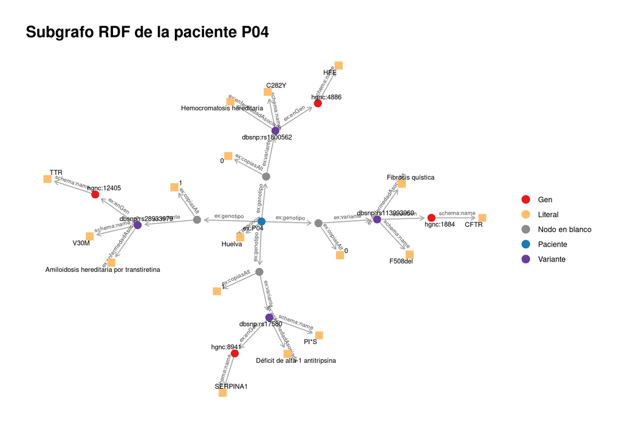

```r
paciente  <- "http://example.org/fdbws#P04"
blancos   <- todas |> filter(s == paciente, tipo_o == "blanco") |> pull(o)
variantes <- todas |> filter(s %in% blancos, tipo_o == "URI") |> pull(o)
genes     <- todas |> filter(s %in% variantes, str_detect(p, "enGen")) |> pull(o)

clases <- todas |>
  filter(str_detect(p, "type")) |>
  transmute(name = s, clase = acortar(o))

aristas <- todas |>
  filter(s %in% c(paciente, blancos, variantes, genes),
         !str_detect(p, "type|cambioProteina|cromosoma")) |>
  # cada literal es un nodo propio: si no, todos los "0" se fundirían en uno
  mutate(to = if_else(tipo_o == "literal", str_c(s, p, o, sep = "|"), o)) |>
  transmute(from = s, to, predicado = acortar(p))

nodos <- tibble(name = unique(c(aristas$from, aristas$to))) |>
  left_join(clases, by = "name") |>
  mutate(clase = case_when(str_detect(name, "\\|")      ~ "Literal",
                           str_detect(name, "^_:")       ~ "Nodo en blanco",
                           clase == "schema:Patient"     ~ "Paciente",
                           clase == "ex:Variante"        ~ "Variante",
                           clase == "schema:Gene"        ~ "Gen"),
         etiqueta = case_when(clase == "Literal"        ~ str_extract(name, "[^|]+$"),
                              clase == "Nodo en blanco" ~ "",
                              TRUE                      ~ acortar(name)))

set.seed(2026)
tbl_graph(nodes = nodos, edges = aristas, node_key = "name") |>
  ggraph(layout = "stress") +
  geom_edge_link(aes(label = predicado), colour = "grey65",
                 label_colour = "grey30", label_size = 2.3,
                 angle_calc = "along", label_dodge = unit(2, "mm"),
                 arrow = arrow(length = unit(2, "mm")),
                 end_cap = circle(3, "mm")) +
  geom_node_point(aes(colour = clase, shape = clase == "Literal"), size = 4) +
  geom_node_text(aes(label = etiqueta), size = 2.7, repel = TRUE) +
  scale_shape_manual(values = c(`FALSE` = 16, `TRUE` = 15), guide = "none") +
  scale_colour_manual(values = c(Paciente = "#1f78b4", Variante = "#6a3d9a",
                                 Gen = "#e31a1c", "Nodo en blanco" = "grey55",
                                 Literal = "#fdbf6f")) +
  labs(colour = NULL, title = "Subgrafo RDF de la paciente P04") +
  theme_graph(base_family = "sans")
```

Leed el grafo siguiendo las flechas desde `ex:P04`: cada arista es una tripleta. Los círculos grises son los genotipos (nodos en blanco), que **solo existen para unir** un paciente con una variante y su número de copias. Los cuadrados son literales: valores sin identidad propia, que nunca pueden ser sujeto de otra tripleta.

### 4.2.2 Vista interactiva: toda la cohorte

Para el grafo completo usamos `visNetwork`, que permite mover nodos, hacer zoom y ver información al pasar el ratón. Esta vez no dibujamos los literales como nodos, sino como información emergente, y coloreamos cada genotipo según el número de copias del alelo alternativo. Así el grafo se convierte también en una visualización genética: los nodos naranjas y rojos son los portadores.

```r
red <- rdf_query(grafo, '
PREFIX ex:     <http://example.org/fdbws#>
PREFIX schema: <https://schema.org/>
SELECT ?pac ?provincia ?gt ?copias ?var ?variante ?enfermedad ?gen ?simbolo
WHERE {
  ?pac ex:provincia ?provincia ; ex:genotipo ?gt .
  ?gt  ex:variante  ?var ; ex:copiasAlt ?copias .
  ?var schema:name  ?variante ; ex:enfermedadAsociada ?enfermedad ;
       ex:enGen     ?gen .
  ?gen schema:name  ?simbolo .
}') |>
  as_tibble()

nodos_red <- bind_rows(
  red |> distinct(id = pac, provincia) |>
    transmute(id, label = str_remove(id, ".*#"), group = "Paciente",
              title = str_c("Provincia: ", provincia)),
  red |> distinct(id = gt, copias) |>
    transmute(id, label = "",
              group = c("0 copias", "1 copia", "2 copias")[copias + 1],
              title = str_c("Genotipo: ", copias, " copia(s) del alelo alternativo")),
  red |> distinct(id = var, variante, enfermedad) |>
    transmute(id, label = variante, group = "Variante", title = enfermedad),
  red |> distinct(id = gen, simbolo) |>
    transmute(id, label = simbolo, group = "Gen", title = acortar(id))
)

aristas_red <- bind_rows(
  red |> distinct(from = pac, to = gt)  |> mutate(title = "ex:genotipo"),
  red |> distinct(from = gt,  to = var) |> mutate(title = "ex:variante"),
  red |> distinct(from = var, to = gen) |> mutate(title = "ex:enGen")
)

visNetwork(nodos_red, aristas_red, height = "550px", width = "100%") |>
  visGroups(groupname = "Paciente", color = "#1f78b4", shape = "dot") |>
  visGroups(groupname = "Variante", color = "#6a3d9a", shape = "diamond") |>
  visGroups(groupname = "Gen",      color = "#e31a1c", shape = "square") |>
  visGroups(groupname = "0 copias", color = "#d9d9d9", size = 6) |>
  visGroups(groupname = "1 copia",  color = "#ff7f00", size = 10) |>
  visGroups(groupname = "2 copias", color = "#b2182b", size = 14) |>
  visNodes(font = list(size = 22)) |>
  visEdges(arrows = "to", color = list(color = "#8c8c8c")) |>
  visOptions(highlightNearest = list(enabled = TRUE, degree = 2),
             nodesIdSelection = list(main = "Seleccionad un nodo")) |>
  visLegend(width = 0.15, position = "right") |>
  visIgraphLayout(layout = "layout_with_fr", randomSeed = 2026)
```

[interactive chart not shown]

Probad a seleccionar la variante V30M en el desplegable: se resaltarán sus genotipos y, a dos saltos, los pacientes que los tienen. Buscad cuáles son portadores y comprobad su provincia pasando el ratón por encima.

## 4.3 Consultar con SPARQL

```r
consulta <- '
PREFIX ex:     <http://example.org/fdbws#>
PREFIX schema: <https://schema.org/>

SELECT ?paciente ?provincia ?variante ?gen ?enfermedad ?copias
WHERE {
  ?p   a schema:Patient ;
       ex:provincia ?provincia ;
       ex:genotipo  ?gt .
  ?gt  ex:variante  ?v ;
       ex:copiasAlt ?copias .
  ?v   schema:name  ?variante ;
       ex:enGen     ?g ;
       ex:enfermedadAsociada ?enfermedad .
  ?g   schema:name  ?gen .
  BIND(STRAFTER(STR(?p), "#") AS ?paciente)
}'

genotipos <- rdf_query(grafo, consulta) |>
  as_tibble() |>
  mutate(copias = as.integer(copias)) |>
  arrange(paciente, gen)

genotipos
```

```
#> # A tibble: 48 × 6
#>    paciente provincia variante gen      enfermedad                        copias
#>    <chr>    <chr>     <chr>    <chr>    <chr>                              <int>
#>  1 P01      Burgos    F508del  CFTR     Fibrosis quística                      0
#>  2 P01      Burgos    C282Y    HFE      Hemocromatosis hereditaria             0
#>  3 P01      Burgos    PI*S     SERPINA1 Déficit de alfa-1 antitripsina         1
#>  4 P01      Burgos    V30M     TTR      Amiloidosis hereditaria por tran…      0
#>  5 P02      Burgos    F508del  CFTR     Fibrosis quística                      0
#>  6 P02      Burgos    C282Y    HFE      Hemocromatosis hereditaria             1
#>  7 P02      Burgos    PI*S     SERPINA1 Déficit de alfa-1 antitripsina         0
#>  8 P02      Burgos    V30M     TTR      Amiloidosis hereditaria por tran…      0
#>  9 P03      Burgos    F508del  CFTR     Fibrosis quística                      0
#> 10 P03      Burgos    C282Y    HFE      Hemocromatosis hereditaria             0
#> # ℹ 38 more rows
```

Comparad esta tabla con `genotipos_json` del nivel 1. Para obtener el nombre del gen y la enfermedad con `tidyjson`, tendríamos que haber hecho a mano varios `left_join()` entre partes del árbol. En el grafo basta con **seguir los enlaces**.

# 5 Análisis genético básico

A partir de aquí volvemos al terreno del tidyverse, que ya conocéis.

## 5.1 Recuento de genotipos

```r
genotipos |>
  mutate(genotipo = factor(copias, levels = 0:2,
                           labels = c("Ref/Ref", "Ref/Alt", "Alt/Alt"))) |>
  count(gen, variante, genotipo) |>
  pivot_wider(names_from = genotipo, values_from = n, values_fill = 0)
```

```
#> # A tibble: 4 × 5
#>   gen      variante `Ref/Ref` `Ref/Alt` `Alt/Alt`
#>   <chr>    <chr>        <int>     <int>     <int>
#> 1 CFTR     F508del         11         1         0
#> 2 HFE      C282Y           10         2         0
#> 3 SERPINA1 PI*S             6         5         1
#> 4 TTR      V30M             9         3         0
```

## 5.2 Frecuencia alélica

Cada persona tiene dos copias de cada cromosoma autosómico. Con *N* individuos hay, por tanto, *2N* alelos. La **frecuencia del alelo alternativo** es:

$$q = \frac{\text{n.º de alelos alternativos}}{2N} =
\frac{n_{\text{Ref/Alt}} + 2\,n_{\text{Alt/Alt}}}{2N}$$

```r
frecuencias <- genotipos |>
  group_by(gen, variante, enfermedad) |>
  summarise(N          = n(),
            portadores = sum(copias > 0),
            alelos_alt = sum(copias),
            q          = alelos_alt / (2 * N),
            .groups    = "drop") |>
  arrange(desc(q))

frecuencias
```

```
#> # A tibble: 4 × 7
#>   gen      variante enfermedad                    N portadores alelos_alt      q
#>   <chr>    <chr>    <chr>                     <int>      <int>      <int>  <dbl>
#> 1 SERPINA1 PI*S     Déficit de alfa-1 antitr…    12          6          7 0.292
#> 2 TTR      V30M     Amiloidosis hereditaria …    12          3          3 0.125
#> 3 HFE      C282Y    Hemocromatosis hereditar…    12          2          2 0.0833
#> 4 CFTR     F508del  Fibrosis quística            12          1          1 0.0417
```

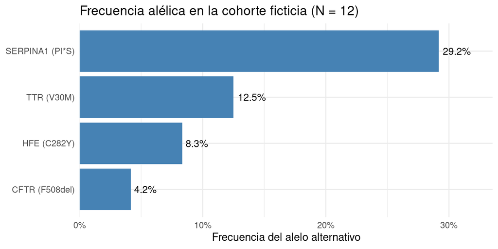

```r
frecuencias |>
  mutate(etiqueta = str_c(gen, " (", variante, ")"),
         etiqueta = fct_reorder(etiqueta, q)) |>
  ggplot(aes(x = q, y = etiqueta)) +
  geom_col(fill = "steelblue") +
  geom_text(aes(label = scales::percent(q, accuracy = 0.1)),
            hjust = -0.15, size = 3.5) +
  scale_x_continuous(labels = scales::percent,
                     expand = expansion(mult = c(0, 0.15))) +
  labs(x = "Frecuencia del alelo alternativo", y = NULL,
       title = "Frecuencia alélica en la cohorte ficticia (N = 12)") +
  theme_minimal()
```

## 5.3 Portadores por provincia

El alelo V30M de *TTR* tiene focos endémicos conocidos en España. Veamos dónde aparecen los portadores en nuestra cohorte:

```r
genotipos |>
  filter(gen == "TTR") |>
  group_by(provincia) |>
  summarise(pacientes = n(), portadores_V30M = sum(copias > 0)) |>
  arrange(desc(portadores_V30M))
```

```
#> # A tibble: 7 × 3
#>   provincia     pacientes portadores_V30M
#>   <chr>             <int>           <int>
#> 1 Huelva                2               2
#> 2 Illes Balears         2               1
#> 3 Asturias              1               0
#> 4 Burgos                3               0
#> 5 León                  1               0
#> 6 Madrid                2               0
#> 7 Sevilla               1               0
```

Con datos reales, este tipo de agregación geográfica es la base de los estudios de efecto fundador.

## 5.4 Equilibrio de Hardy-Weinberg

Si una población se aparea al azar y no hay selección, migración ni mutación, las frecuencias genotípicas esperadas a partir de las alélicas son *p²*, *2pq* y *q²*, con *p = 1 − q*. Comprobémoslo para PI*S:

```r
pis <- genotipos |> filter(variante == "PI*S")

N <- nrow(pis)
q <- sum(pis$copias) / (2 * N)
p <- 1 - q

tibble(genotipo  = c("Ref/Ref", "Ref/Alt", "Alt/Alt"),
       observado = tabulate(pis$copias + 1, nbins = 3),
       esperado  = round(N * c(p^2, 2 * p * q, q^2), 2))
```

```
#> # A tibble: 3 × 3
#>   genotipo observado esperado
#>   <chr>        <int>    <dbl>
#> 1 Ref/Ref          6     6.02
#> 2 Ref/Alt          5     4.96
#> 3 Alt/Alt          1     1.02
```

Las cifras observadas y esperadas son muy parecidas. Con solo 12 individuos, sin embargo, **ningún contraste estadístico tendría potencia** para detectar una desviación. Tomadlo como un ejercicio de cálculo, no como una conclusión.

## 5.5 Cerrar el círculo: devolver el resultado al grafo

Un resultado analítico también es un dato que merece publicarse de forma vinculada. Añadimos la frecuencia alélica calculada como nuevas tripletas y exportamos de nuevo a JSON-LD, con nuestro contexto original:

```r
# Correspondencia nombre de variante -> URI, obtenida del propio grafo
uris <- rdf_query(grafo, '
  PREFIX schema: <https://schema.org/>
  PREFIX ex:     <http://example.org/fdbws#>
  SELECT ?uri ?variante WHERE { ?uri a ex:Variante ; schema:name ?variante }')

frecuencias |>
  left_join(uris, by = "variante") |>
  select(uri, q) |>
  pwalk(\(uri, q) rdf_add(grafo, subject = uri,
                          predicate = "http://example.org/fdbws#frecuenciaAlelica",
                          object = round(q, 4)))

rdf_serialize(grafo, "variantes_es_con_frecuencias.jsonld", format = "jsonld")

contexto_original <- jsonlite::fromJSON("variantes_es.jsonld",
                                        simplifyVector = FALSE)["@context"] |>
  jsonlite::toJSON(auto_unbox = TRUE)

read_file("variantes_es_con_frecuencias.jsonld") |>
  jsonld_compact(contexto_original) |>
  jsonlite::fromJSON(simplifyVector = FALSE) |>
  pluck("@graph") |>
  keep(\(nodo) identical(nodo$`@id`, "dbsnp:rs17580")) |>
  jsonlite::toJSON(auto_unbox = TRUE, pretty = TRUE)
```

```
#> [
#>   {
#>     "@id": "dbsnp:rs17580",
#>     "@type": "Variante",
#>     "cambio": "p.Glu288Val",
#>     "enGen": "hgnc:8941",
#>     "enfermedad": "Déficit de alfa-1 antitripsina",
#>     "ex:frecuenciaAlelica": {
#>       "@type": "xsd:decimal",
#>       "@value": "0.2917"
#>     },
#>     "nombre": "PI*S"
#>   }
#> ]
```

El nodo de PI*S incluye ahora la propiedad `ex:frecuenciaAlelica`, que no estaba en el documento original. El ciclo completo ha sido: JSON-LD → grafo RDF → tabla *tidy* → análisis → grafo RDF → JSON-LD.

# Para pensar y practicar

## 5.6 Preguntas de reflexión

1. ¿Por qué hemos usado `https://identifiers.org/dbsnp:rs17580` como identificador de la variante, en lugar de una URI de nuestra universidad? ¿Qué ganaríamos si otro grupo de investigación hiciera lo mismo?
2. La propiedad `ex:cromosoma` pertenece a un espacio de nombres inventado (`example.org`). ¿Qué problema plantea eso para la interoperabilidad? Buscad si schema.org o Bioschemas ofrecen una propiedad más adecuada.
3. En el nivel 1 obtuvisteis una tabla *tidy* con `tidyjson`, y en el nivel 3 otra con SPARQL. ¿En qué situaciones preferiríais cada camino?

## 5.7 Ejercicios

1. **Nuevo paciente.** Añadid al documento un paciente `ex:P13` de Valverde del Camino (Huelva), heterocigoto para V30M y homocigoto de referencia para el resto. Volved a ejecutar el cuaderno y comprobad cómo cambian las frecuencias.
2. **Nueva variante.** Incorporad la variante PI*Z de *SERPINA1* (`dbsnp:rs28929474`, p.Glu366Lys), asociada a la forma más grave del déficit de alfa-1 antitripsina. Inventad los genotipos de los doce pacientes.
3. **Consulta SPARQL.** Escribid una consulta que devuelva solo los pacientes portadores de al menos una variante en el cromosoma 14. Pista: necesitáis `FILTER(?copias > 0)`.
4. **Metadatos (opcional).** Añadid al `@graph` un nodo de tipo `dcat:Dataset` (`http://www.w3.org/ns/dcat#Dataset`) que describa vuestro conjunto de datos, con título (`dcterms:title`), editor (`dcterms:publisher`) y licencia (`dcterms:license`). Es el mismo vocabulario que exigen el portal datos.gob.es (perfil DCAT-AP-ES) y el futuro Espacio Europeo de Datos de Salud (perfil HealthDCAT-AP).

## 5.8 Para saber más

- W3C (2020). *JSON-LD 1.1*. https://www.w3.org/TR/json-ld11/
- JSON-LD Playground, para experimentar sin instalar nada: https://json-ld.org/playground/
- JSON Crack, para visualizar cualquier JSON como diagrama en el navegador: https://jsoncrack.com/
- Pedersen, T. L. *ggraph: An Implementation of Grammar of Graphics for Graphs and Networks*. https://ggraph.data-imaginist.com/
- Los datos reales de frecuencias de variantes en población española pueden consultarse en el *Collaborative Spanish Variant Server* (CSVS), mantenido en el marco del CIBERER.